# **Titanic Kaggle Competition - EDA**

## **Data Dictionary**

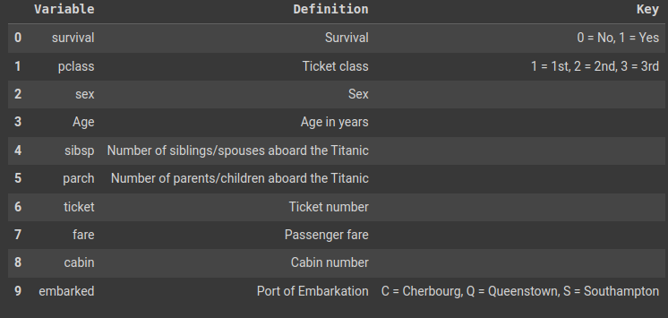

**Check and install the dependencies**

```python
!curl -sSL https://raw.githubusercontent.com/K14aNB/titanic-kaggle-competition/main/requirements.txt
```

```
mlflow
pandas==2.2.2
scikit-learn==1.4.2
seaborn==0.13.1
PyYAML
xgboost
download-kaggle-dataset @ git+https://github.com/K14aNB/download-kaggle-dataset.git@main
env_setup @ git+https://github.com/K14aNB/setup-notebook-environment.git@main
```

```python
# Run this command in terminal before running this notebook as .py script
# Installs dependencies from requirements.txt present in the repo
%%capture
!pip install -r https://raw.githubusercontent.com/K14aNB/titanic-kaggle-competition/main/requirements.txt
```

**Import the libraries**

```python
import numpy as np
import pandas as pd
import matplotlib.pyplot as plt
import seaborn as sns
from sklearn.base import BaseEstimator,TransformerMixin
from sklearn.impute import SimpleImputer
from sklearn.preprocessing import OneHotEncoder
from sklearn.compose import ColumnTransformer
from sklearn.linear_model import LogisticRegression
from sklearn.tree import DecisionTreeClassifier
from sklearn.ensemble import RandomForestClassifier
from sklearn.model_selection import cross_validate
from sklearn.pipeline import Pipeline
from xgboost import XGBClassifier
import mlflow
import env_setup
import os
```

**Environment Setup**

```python
result_path=env_setup.setup(repo_name='titanic-kaggle-competition',nb_name='Titanic-Kaggle-Competition-EDA')
```

```
Found the repo
MLFlow setup with Dagshub is done!!
```

**Read the data**

```python
titanic_train=pd.read_csv(os.path.join(result_path,'train.csv'))
```

```python
titanic_train.head()
```

|  | PassengerId | Survived | Pclass | Name | Sex | Age | SibSp | Parch | Ticket | Fare | Cabin | Embarked |
| --- | --- | --- | --- | --- | --- | --- | --- | --- | --- | --- | --- | --- |
| 0 | 1 | 0 | 3 | Braund, Mr. Owen Harris | male | 22.0 | 1 | 0 | A/5 21171 | 7.2500 | NaN | S |
| 1 | 2 | 1 | 1 | Cumings, Mrs. John Bradley (Florence Briggs Th... | female | 38.0 | 1 | 0 | PC 17599 | 71.2833 | C85 | C |
| 2 | 3 | 1 | 3 | Heikkinen, Miss. Laina | female | 26.0 | 0 | 0 | STON/O2. 3101282 | 7.9250 | NaN | S |
| 3 | 4 | 1 | 1 | Futrelle, Mrs. Jacques Heath (Lily May Peel) | female | 35.0 | 1 | 0 | 113803 | 53.1000 | C123 | S |
| 4 | 5 | 0 | 3 | Allen, Mr. William Henry | male | 35.0 | 0 | 0 | 373450 | 8.0500 | NaN | S |

```python
titanic_train.info()
```

```
<class 'pandas.core.frame.DataFrame'>
RangeIndex: 891 entries, 0 to 890
Data columns (total 12 columns):
 #   Column       Non-Null Count  Dtype
---  ------       --------------  -----
 0   PassengerId  891 non-null    int64
 1   Survived     891 non-null    int64
 2   Pclass       891 non-null    int64
 3   Name         891 non-null    object
 4   Sex          891 non-null    object
 5   Age          714 non-null    float64
 6   SibSp        891 non-null    int64
 7   Parch        891 non-null    int64
 8   Ticket       891 non-null    object
 9   Fare         891 non-null    float64
 10  Cabin        204 non-null    object
 11  Embarked     889 non-null    object
dtypes: float64(2), int64(5), object(5)
memory usage: 83.7+ KB
```

```python
titanic_train.describe()
```

|  | PassengerId | Survived | Pclass | Age | SibSp | Parch | Fare |
| --- | --- | --- | --- | --- | --- | --- | --- |
| count | 891.000000 | 891.000000 | 891.000000 | 714.000000 | 891.000000 | 891.000000 | 891.000000 |
| mean | 446.000000 | 0.383838 | 2.308642 | 29.699118 | 0.523008 | 0.381594 | 32.204208 |
| std | 257.353842 | 0.486592 | 0.836071 | 14.526497 | 1.102743 | 0.806057 | 49.693429 |
| min | 1.000000 | 0.000000 | 1.000000 | 0.420000 | 0.000000 | 0.000000 | 0.000000 |
| 25% | 223.500000 | 0.000000 | 2.000000 | 20.125000 | 0.000000 | 0.000000 | 7.910400 |
| 50% | 446.000000 | 0.000000 | 3.000000 | 28.000000 | 0.000000 | 0.000000 | 14.454200 |
| 75% | 668.500000 | 1.000000 | 3.000000 | 38.000000 | 1.000000 | 0.000000 | 31.000000 |
| max | 891.000000 | 1.000000 | 3.000000 | 80.000000 | 8.000000 | 6.000000 | 512.329200 |

### **Exploratory Data Analysis**

**Check for missing values**

```python
titanic_train.isna().sum()
```

```
PassengerId      0
Survived         0
Pclass           0
Name             0
Sex              0
Age            177
SibSp            0
Parch            0
Ticket           0
Fare             0
Cabin          687
Embarked         2
dtype: int64
```

Age column has lot of missing values.  
Cabin column can be dropped due to significant percentage of missing values  
Embarked column missing values can be imputed the mode

```python
titanic_train['Embarked'].value_counts()
```

```
Embarked
S    644
C    168
Q     77
Name: count, dtype: int64
```

**Check for duplicated rows**

```python
titanic_train.duplicated().sum().sum()
```

```
0
```

**Inspect `Fare` column**

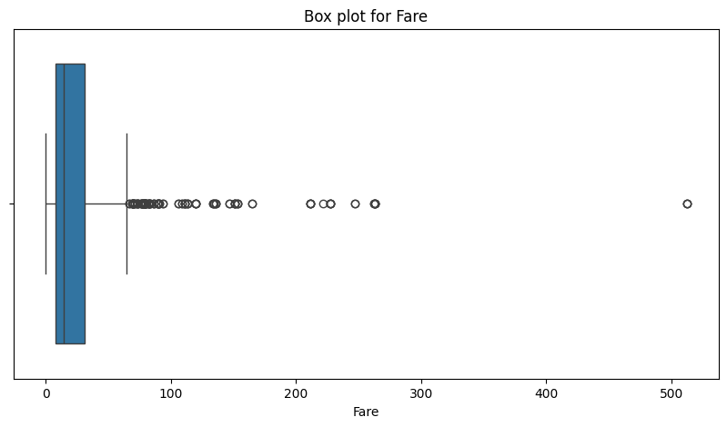

```python
fig=plt.figure(figsize=(10,5))
sns.boxplot(x='Fare',data=titanic_train)
plt.xlabel('Fare')
plt.title('Box plot for Fare')
plt.show()
```

There seem to be outliers present in `Fare` column. We can keep this for now for the baseline model

**Distribution of `Fare` column**

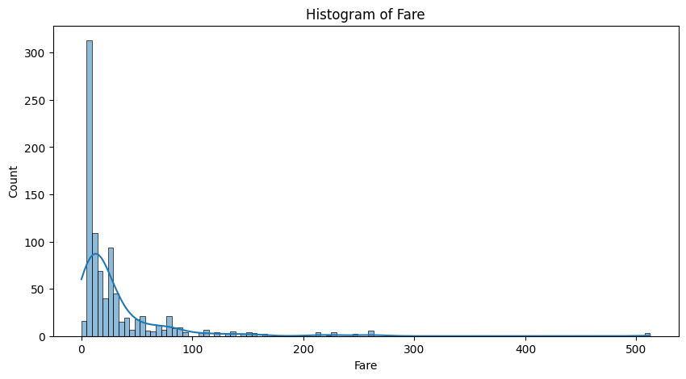

```python
fig=plt.figure(figsize=(10,5))
sns.histplot(x='Fare',data=titanic_train,kde=True)
plt.xlabel('Fare')
plt.title('Histogram of Fare')
plt.show()
```

`Fare` column has a long-tail distribution.  
We need to perform Log1p transformation.

**Relationship between `Fare` and `Pclass`**

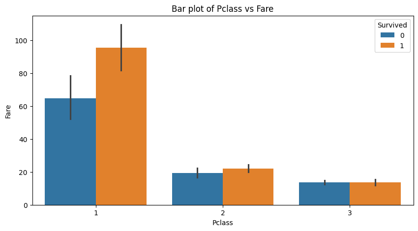

```python
fig=plt.figure(figsize=(10,5))
sns.barplot(x='Pclass',y='Fare',hue='Survived',data=titanic_train)
plt.xlabel('Pclass')
plt.ylabel('Fare')
plt.title('Bar plot of Pclass vs Fare')
plt.show()
```

Clearly the bar plot indicates that people from Higher Socio-economic background who paid higher fare had better Survival rate.  
`Fare` and `Pclass` have strong relationship with Survival

**Inspect `Parch` and `SibSp` columns**

```python
titanic_train['Parch'].value_counts()
```

```
Parch
0    678
1    118
2     80
5      5
3      5
4      4
6      1
Name: count, dtype: int64
```

```python
titanic_train['SibSp'].value_counts()
```

```
SibSp
0    608
1    209
2     28
4     18
3     16
8      7
5      5
Name: count, dtype: int64
```

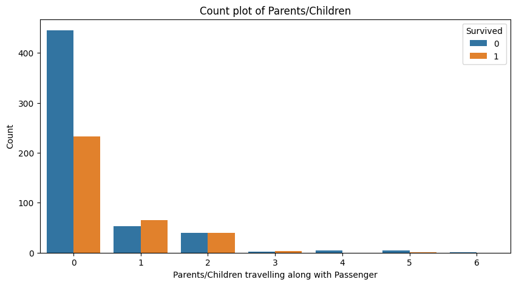

```python
# Count plot of Parch
fig=plt.figure(figsize=(10,5))
sns.countplot(x='Parch',hue='Survived',data=titanic_train)
plt.xlabel('Parents/Children travelling along with Passenger')
plt.ylabel('Count')
plt.title('Count plot of Parents/Children')
plt.show()
```

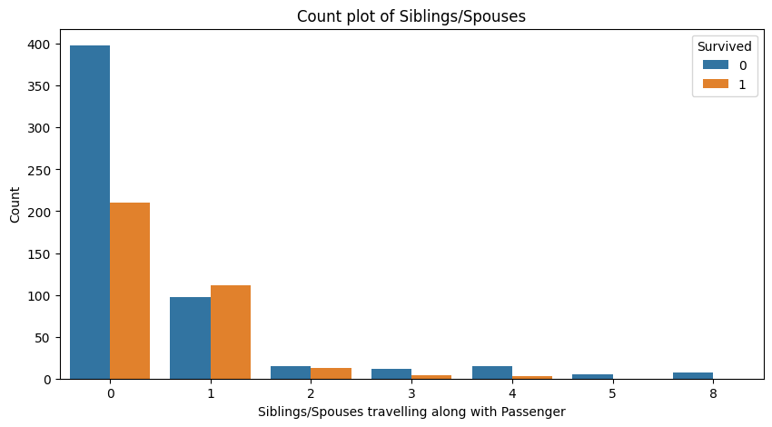

```python
# Count plot of SibSp
fig=plt.figure(figsize=(10,5))
sns.countplot(x='SibSp',hue='Survived',data=titanic_train)
plt.xlabel('Siblings/Spouses travelling along with Passenger')
plt.ylabel('Count')
plt.title('Count plot of Siblings/Spouses')
plt.show()
```

Both `Parch` and `SibSp` show that people travelling alone are more in number and also their Survival rate is lower than people travelling with Family. Although the dataset mentions the value 0 is given for Children travelling with nannies, we can make reasonable assumption that people travelling alone (without family) are of category 0 in `Parch` and `SibSp`

We can possibly combine `Parch` and `SibSp` into a single column with binary values to indicate whether they are travelling alone or with family

```python
X_analysis=titanic_train.copy()
X_analysis.loc[(X_analysis['Parch']==0)|(X_analysis['SibSp']==0),'Travelling_Alone']=1
X_analysis.loc[(X_analysis['Parch']>0)|(X_analysis['SibSp']>0),'Travelling_Alone']=0
```

```python
X_analysis['Travelling_Alone'].value_counts()
```

```
Travelling_Alone
1.0    537
0.0    354
Name: count, dtype: int64
```

**Inspect Relation between `Sex` and `Travelling_Alone` columns based on Survival**

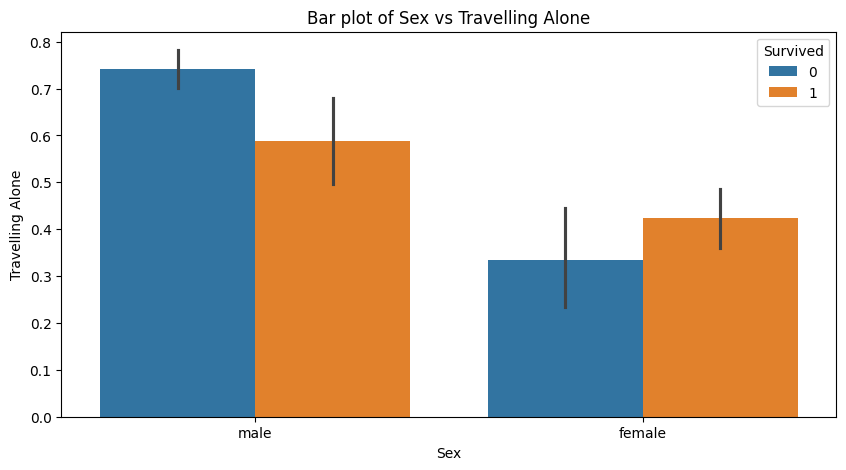

```python
fig=plt.figure(figsize=(10,5))
sns.barplot(x='Sex',y='Travelling_Alone',hue='Survived',data=X_analysis)
plt.xlabel('Sex')
plt.ylabel('Travelling Alone')
plt.title('Bar plot of Sex vs Travelling Alone')
plt.show()
```

From the bar plot, it clear that female passengers who were travelling alone had a higher survival rate while Male passengers with families had a higher Survival rate

**Inspect `Embarked` column**

```python
titanic_train['Embarked'].value_counts()
```

```
Embarked
S    644
C    168
Q     77
Name: count, dtype: int64
```

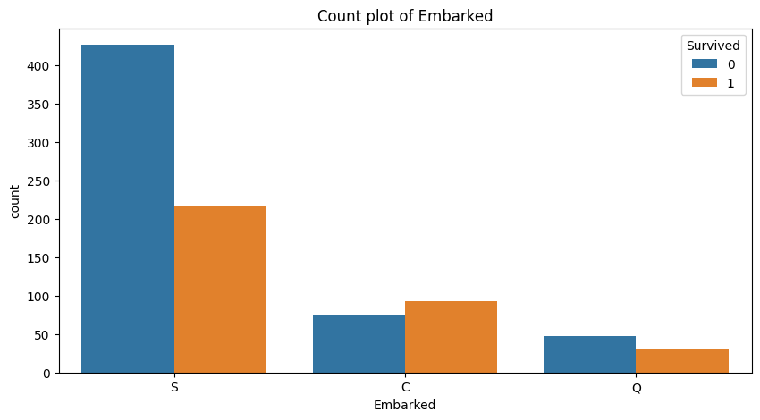

```python
fig=plt.figure(figsize=(10,5))
sns.countplot(x='Embarked',hue='Survived',data=titanic_train)
plt.xlabel('Embarked')
plt.title('Count plot of Embarked')
plt.show()
```

People who embarked at Southhampton had a low survival rate.

**Inspect Age column**

```python
titanic_train['Age'].unique().shape
```

```
(89,)
```

```python
# Age group 0-17
titanic_train.loc[(titanic_train['Age']>0)&(titanic_train['Age']<18)]
```

|  | PassengerId | Survived | Pclass | Name | Sex | Age | SibSp | Parch | Ticket | Fare | Cabin | Embarked |
| --- | --- | --- | --- | --- | --- | --- | --- | --- | --- | --- | --- | --- |
| 7 | 8 | 0 | 3 | Palsson, Master. Gosta Leonard | male | 2.0 | 3 | 1 | 349909 | 21.0750 | NaN | S |
| 9 | 10 | 1 | 2 | Nasser, Mrs. Nicholas (Adele Achem) | female | 14.0 | 1 | 0 | 237736 | 30.0708 | NaN | C |
| 10 | 11 | 1 | 3 | Sandstrom, Miss. Marguerite Rut | female | 4.0 | 1 | 1 | PP 9549 | 16.7000 | G6 | S |
| 14 | 15 | 0 | 3 | Vestrom, Miss. Hulda Amanda Adolfina | female | 14.0 | 0 | 0 | 350406 | 7.8542 | NaN | S |
| 16 | 17 | 0 | 3 | Rice, Master. Eugene | male | 2.0 | 4 | 1 | 382652 | 29.1250 | NaN | Q |
| ... | ... | ... | ... | ... | ... | ... | ... | ... | ... | ... | ... | ... |
| 850 | 851 | 0 | 3 | Andersson, Master. Sigvard Harald Elias | male | 4.0 | 4 | 2 | 347082 | 31.2750 | NaN | S |
| 852 | 853 | 0 | 3 | Boulos, Miss. Nourelain | female | 9.0 | 1 | 1 | 2678 | 15.2458 | NaN | C |
| 853 | 854 | 1 | 1 | Lines, Miss. Mary Conover | female | 16.0 | 0 | 1 | PC 17592 | 39.4000 | D28 | S |
| 869 | 870 | 1 | 3 | Johnson, Master. Harold Theodor | male | 4.0 | 1 | 1 | 347742 | 11.1333 | NaN | S |
| 875 | 876 | 1 | 3 | Najib, Miss. Adele Kiamie "Jane" | female | 15.0 | 0 | 0 | 2667 | 7.2250 | NaN | C |

113 rows × 12 columns

```python
# Age group 18-35
titanic_train.loc[(titanic_train['Age']>=18)&(titanic_train['Age']<36)]
```

|  | PassengerId | Survived | Pclass | Name | Sex | Age | SibSp | Parch | Ticket | Fare | Cabin | Embarked |
| --- | --- | --- | --- | --- | --- | --- | --- | --- | --- | --- | --- | --- |
| 0 | 1 | 0 | 3 | Braund, Mr. Owen Harris | male | 22.0 | 1 | 0 | A/5 21171 | 7.2500 | NaN | S |
| 2 | 3 | 1 | 3 | Heikkinen, Miss. Laina | female | 26.0 | 0 | 0 | STON/O2. 3101282 | 7.9250 | NaN | S |
| 3 | 4 | 1 | 1 | Futrelle, Mrs. Jacques Heath (Lily May Peel) | female | 35.0 | 1 | 0 | 113803 | 53.1000 | C123 | S |
| 4 | 5 | 0 | 3 | Allen, Mr. William Henry | male | 35.0 | 0 | 0 | 373450 | 8.0500 | NaN | S |
| 8 | 9 | 1 | 3 | Johnson, Mrs. Oscar W (Elisabeth Vilhelmina Berg) | female | 27.0 | 0 | 2 | 347742 | 11.1333 | NaN | S |
| ... | ... | ... | ... | ... | ... | ... | ... | ... | ... | ... | ... | ... |
| 884 | 885 | 0 | 3 | Sutehall, Mr. Henry Jr | male | 25.0 | 0 | 0 | SOTON/OQ 392076 | 7.0500 | NaN | S |
| 886 | 887 | 0 | 2 | Montvila, Rev. Juozas | male | 27.0 | 0 | 0 | 211536 | 13.0000 | NaN | S |
| 887 | 888 | 1 | 1 | Graham, Miss. Margaret Edith | female | 19.0 | 0 | 0 | 112053 | 30.0000 | B42 | S |
| 889 | 890 | 1 | 1 | Behr, Mr. Karl Howell | male | 26.0 | 0 | 0 | 111369 | 30.0000 | C148 | C |
| 890 | 891 | 0 | 3 | Dooley, Mr. Patrick | male | 32.0 | 0 | 0 | 370376 | 7.7500 | NaN | Q |

384 rows × 12 columns

```python
# Age group 36-53
titanic_train.loc[(titanic_train['Age']>=36)&(titanic_train['Age']<54)]
```

|  | PassengerId | Survived | Pclass | Name | Sex | Age | SibSp | Parch | Ticket | Fare | Cabin | Embarked |
| --- | --- | --- | --- | --- | --- | --- | --- | --- | --- | --- | --- | --- |
| 1 | 2 | 1 | 1 | Cumings, Mrs. John Bradley (Florence Briggs Th... | female | 38.0 | 1 | 0 | PC 17599 | 71.2833 | C85 | C |
| 13 | 14 | 0 | 3 | Andersson, Mr. Anders Johan | male | 39.0 | 1 | 5 | 347082 | 31.2750 | NaN | S |
| 25 | 26 | 1 | 3 | Asplund, Mrs. Carl Oscar (Selma Augusta Emilia... | female | 38.0 | 1 | 5 | 347077 | 31.3875 | NaN | S |
| 30 | 31 | 0 | 1 | Uruchurtu, Don. Manuel E | male | 40.0 | 0 | 0 | PC 17601 | 27.7208 | NaN | C |
| 35 | 36 | 0 | 1 | Holverson, Mr. Alexander Oskar | male | 42.0 | 1 | 0 | 113789 | 52.0000 | NaN | S |
| ... | ... | ... | ... | ... | ... | ... | ... | ... | ... | ... | ... | ... |
| 862 | 863 | 1 | 1 | Swift, Mrs. Frederick Joel (Margaret Welles Ba... | female | 48.0 | 0 | 0 | 17466 | 25.9292 | D17 | S |
| 865 | 866 | 1 | 2 | Bystrom, Mrs. (Karolina) | female | 42.0 | 0 | 0 | 236852 | 13.0000 | NaN | S |
| 871 | 872 | 1 | 1 | Beckwith, Mrs. Richard Leonard (Sallie Monypeny) | female | 47.0 | 1 | 1 | 11751 | 52.5542 | D35 | S |
| 873 | 874 | 0 | 3 | Vander Cruyssen, Mr. Victor | male | 47.0 | 0 | 0 | 345765 | 9.0000 | NaN | S |
| 885 | 886 | 0 | 3 | Rice, Mrs. William (Margaret Norton) | female | 39.0 | 0 | 5 | 382652 | 29.1250 | NaN | Q |

167 rows × 12 columns

```python
# Age group 54-71
titanic_train.loc[(titanic_train['Age']>=54)&(titanic_train['Age']<72)]
```

|  | PassengerId | Survived | Pclass | Name | Sex | Age | SibSp | Parch | Ticket | Fare | Cabin | Embarked |
| --- | --- | --- | --- | --- | --- | --- | --- | --- | --- | --- | --- | --- |
| 6 | 7 | 0 | 1 | McCarthy, Mr. Timothy J | male | 54.0 | 0 | 0 | 17463 | 51.8625 | E46 | S |
| 11 | 12 | 1 | 1 | Bonnell, Miss. Elizabeth | female | 58.0 | 0 | 0 | 113783 | 26.5500 | C103 | S |
| 15 | 16 | 1 | 2 | Hewlett, Mrs. (Mary D Kingcome) | female | 55.0 | 0 | 0 | 248706 | 16.0000 | NaN | S |
| 33 | 34 | 0 | 2 | Wheadon, Mr. Edward H | male | 66.0 | 0 | 0 | C.A. 24579 | 10.5000 | NaN | S |
| 54 | 55 | 0 | 1 | Ostby, Mr. Engelhart Cornelius | male | 65.0 | 0 | 1 | 113509 | 61.9792 | B30 | C |
| 94 | 95 | 0 | 3 | Coxon, Mr. Daniel | male | 59.0 | 0 | 0 | 364500 | 7.2500 | NaN | S |
| 96 | 97 | 0 | 1 | Goldschmidt, Mr. George B | male | 71.0 | 0 | 0 | PC 17754 | 34.6542 | A5 | C |
| 116 | 117 | 0 | 3 | Connors, Mr. Patrick | male | 70.5 | 0 | 0 | 370369 | 7.7500 | NaN | Q |
| 124 | 125 | 0 | 1 | White, Mr. Percival Wayland | male | 54.0 | 0 | 1 | 35281 | 77.2875 | D26 | S |
| 152 | 153 | 0 | 3 | Meo, Mr. Alfonzo | male | 55.5 | 0 | 0 | A.5. 11206 | 8.0500 | NaN | S |
| 170 | 171 | 0 | 1 | Van der hoef, Mr. Wyckoff | male | 61.0 | 0 | 0 | 111240 | 33.5000 | B19 | S |
| 174 | 175 | 0 | 1 | Smith, Mr. James Clinch | male | 56.0 | 0 | 0 | 17764 | 30.6958 | A7 | C |
| 195 | 196 | 1 | 1 | Lurette, Miss. Elise | female | 58.0 | 0 | 0 | PC 17569 | 146.5208 | B80 | C |
| 232 | 233 | 0 | 2 | Sjostedt, Mr. Ernst Adolf | male | 59.0 | 0 | 0 | 237442 | 13.5000 | NaN | S |
| 249 | 250 | 0 | 2 | Carter, Rev. Ernest Courtenay | male | 54.0 | 1 | 0 | 244252 | 26.0000 | NaN | S |
| 252 | 253 | 0 | 1 | Stead, Mr. William Thomas | male | 62.0 | 0 | 0 | 113514 | 26.5500 | C87 | S |
| 268 | 269 | 1 | 1 | Graham, Mrs. William Thompson (Edith Junkins) | female | 58.0 | 0 | 1 | PC 17582 | 153.4625 | C125 | S |
| 275 | 276 | 1 | 1 | Andrews, Miss. Kornelia Theodosia | female | 63.0 | 1 | 0 | 13502 | 77.9583 | D7 | S |
| 280 | 281 | 0 | 3 | Duane, Mr. Frank | male | 65.0 | 0 | 0 | 336439 | 7.7500 | NaN | Q |
| 317 | 318 | 0 | 2 | Moraweck, Dr. Ernest | male | 54.0 | 0 | 0 | 29011 | 14.0000 | NaN | S |
| 326 | 327 | 0 | 3 | Nysveen, Mr. Johan Hansen | male | 61.0 | 0 | 0 | 345364 | 6.2375 | NaN | S |
| 366 | 367 | 1 | 1 | Warren, Mrs. Frank Manley (Anna Sophia Atkinson) | female | 60.0 | 1 | 0 | 110813 | 75.2500 | D37 | C |
| 438 | 439 | 0 | 1 | Fortune, Mr. Mark | male | 64.0 | 1 | 4 | 19950 | 263.0000 | C23 C25 C27 | S |
| 456 | 457 | 0 | 1 | Millet, Mr. Francis Davis | male | 65.0 | 0 | 0 | 13509 | 26.5500 | E38 | S |
| 467 | 468 | 0 | 1 | Smart, Mr. John Montgomery | male | 56.0 | 0 | 0 | 113792 | 26.5500 | NaN | S |
| 483 | 484 | 1 | 3 | Turkula, Mrs. (Hedwig) | female | 63.0 | 0 | 0 | 4134 | 9.5875 | NaN | S |
| 487 | 488 | 0 | 1 | Kent, Mr. Edward Austin | male | 58.0 | 0 | 0 | 11771 | 29.7000 | B37 | C |
| 492 | 493 | 0 | 1 | Molson, Mr. Harry Markland | male | 55.0 | 0 | 0 | 113787 | 30.5000 | C30 | S |
| 493 | 494 | 0 | 1 | Artagaveytia, Mr. Ramon | male | 71.0 | 0 | 0 | PC 17609 | 49.5042 | NaN | C |
| 496 | 497 | 1 | 1 | Eustis, Miss. Elizabeth Mussey | female | 54.0 | 1 | 0 | 36947 | 78.2667 | D20 | C |
| 513 | 514 | 1 | 1 | Rothschild, Mrs. Martin (Elizabeth L. Barrett) | female | 54.0 | 1 | 0 | PC 17603 | 59.4000 | NaN | C |
| 545 | 546 | 0 | 1 | Nicholson, Mr. Arthur Ernest | male | 64.0 | 0 | 0 | 693 | 26.0000 | NaN | S |
| 555 | 556 | 0 | 1 | Wright, Mr. George | male | 62.0 | 0 | 0 | 113807 | 26.5500 | NaN | S |
| 570 | 571 | 1 | 2 | Harris, Mr. George | male | 62.0 | 0 | 0 | S.W./PP 752 | 10.5000 | NaN | S |
| 582 | 583 | 0 | 2 | Downton, Mr. William James | male | 54.0 | 0 | 0 | 28403 | 26.0000 | NaN | S |
| 587 | 588 | 1 | 1 | Frolicher-Stehli, Mr. Maxmillian | male | 60.0 | 1 | 1 | 13567 | 79.2000 | B41 | C |
| 625 | 626 | 0 | 1 | Sutton, Mr. Frederick | male | 61.0 | 0 | 0 | 36963 | 32.3208 | D50 | S |
| 626 | 627 | 0 | 2 | Kirkland, Rev. Charles Leonard | male | 57.0 | 0 | 0 | 219533 | 12.3500 | NaN | Q |
| 647 | 648 | 1 | 1 | Simonius-Blumer, Col. Oberst Alfons | male | 56.0 | 0 | 0 | 13213 | 35.5000 | A26 | C |
| 659 | 660 | 0 | 1 | Newell, Mr. Arthur Webster | male | 58.0 | 0 | 2 | 35273 | 113.2750 | D48 | C |
| 672 | 673 | 0 | 2 | Mitchell, Mr. Henry Michael | male | 70.0 | 0 | 0 | C.A. 24580 | 10.5000 | NaN | S |
| 684 | 685 | 0 | 2 | Brown, Mr. Thomas William Solomon | male | 60.0 | 1 | 1 | 29750 | 39.0000 | NaN | S |
| 694 | 695 | 0 | 1 | Weir, Col. John | male | 60.0 | 0 | 0 | 113800 | 26.5500 | NaN | S |
| 745 | 746 | 0 | 1 | Crosby, Capt. Edward Gifford | male | 70.0 | 1 | 1 | WE/P 5735 | 71.0000 | B22 | S |
| 772 | 773 | 0 | 2 | Mack, Mrs. (Mary) | female | 57.0 | 0 | 0 | S.O./P.P. 3 | 10.5000 | E77 | S |
| 774 | 775 | 1 | 2 | Hocking, Mrs. Elizabeth (Eliza Needs) | female | 54.0 | 1 | 3 | 29105 | 23.0000 | NaN | S |
| 829 | 830 | 1 | 1 | Stone, Mrs. George Nelson (Martha Evelyn) | female | 62.0 | 0 | 0 | 113572 | 80.0000 | B28 | NaN |
| 879 | 880 | 1 | 1 | Potter, Mrs. Thomas Jr (Lily Alexenia Wilson) | female | 56.0 | 0 | 1 | 11767 | 83.1583 | C50 | C |

```python
# Age group 72-89
titanic_train.loc[(titanic_train['Age']>=72)&(titanic_train['Age']<90)]
```

|  | PassengerId | Survived | Pclass | Name | Sex | Age | SibSp | Parch | Ticket | Fare | Cabin | Embarked |
| --- | --- | --- | --- | --- | --- | --- | --- | --- | --- | --- | --- | --- |
| 630 | 631 | 1 | 1 | Barkworth, Mr. Algernon Henry Wilson | male | 80.0 | 0 | 0 | 27042 | 30.000 | A23 | S |
| 851 | 852 | 0 | 3 | Svensson, Mr. Johan | male | 74.0 | 0 | 0 | 347060 | 7.775 | NaN | S |

```python
corr=titanic_train.corr(numeric_only=True)
```

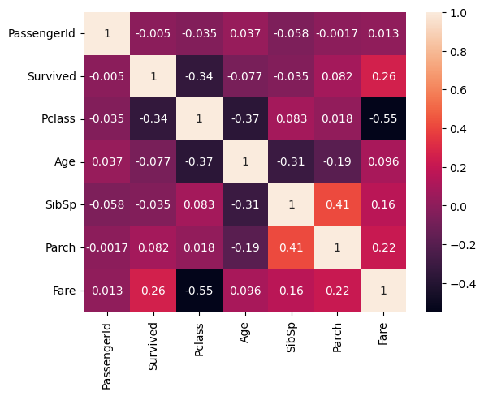

```python
sns.heatmap(corr,annot=True)
```

**Split Predictors and Target**

```python
y=titanic_train.loc[:,'Survived']
X=titanic_train.drop(['Survived'],axis=1)
```

```python
params={
    'num_impute_strategy':'median',
    'num_fill_value':'NA',
    'cat_impute_strategy':'most_frequent',
    'lr_penalty': 'l2',
    'logistic_solver':'lbfgs',
    'random_state':0,
    'max_iter':200,
    'dt_criterion':'gini',
    'dt_max_depth':6,
    'dt_min_samples_split':2,
    'dt_min_samples_leaf':1,
    'rf_criterion':'gini',
    'rf_max_depth':5,
    'rf_min_samples_split':2,
    'rf_min_samples_leaf':1,
    'cv_folds':8
}
```

### **Preprocessing**

```python
# Columns to drop
cols_to_drop=['PassengerId','Name','Ticket','Cabin']
```

```python
# Separate numerical and categorical columns
num_cols=[col for col in X.columns if X[col].dtype in ['int32','int64','float32','float64'] and col not in cols_to_drop]
cat_cols=[col for col in X.columns if X[col].dtype=='object' and col not in cols_to_drop]
```

```python
print(num_cols)
print(cat_cols)
```

```
['Pclass', 'Age', 'SibSp', 'Parch', 'Fare']
['Sex', 'Embarked']
```

**Impute missing values for numerical columns**

```python
# Initialize SimpleImputer to impute missing values for numerical columns
if params.get('num_impute_strategy')=='constant':
    numerical_imputer=SimpleImputer(strategy=params.get('num_impute_strategy'),fill_value=params.get('num_fill_value'))
else:
    numerical_imputer=SimpleImputer(strategy=params.get('num_impute_strategy'))
```

**Numerical Pipeline Steps**

```python
numerical_pipeline=Pipeline(steps=[
    ('numerical_imputer',numerical_imputer),
])
```

**Impute missing values for categorical variables**

```python
# Initialize SimpleImputer to impute missing values for categorical columns
categorical_imputer=SimpleImputer(strategy=params.get('cat_impute_strategy'))
```

**Encode categorical variables**

```python
# Initialize OneHotEncoder to encode categorical variables
cat_encoder=OneHotEncoder(handle_unknown='ignore',sparse_output=False)
```

**Categorical Pipeline Steps**

```python
categorical_pipeline=Pipeline(steps=[
    ('categorical_imputer',categorical_imputer),
    ('categorical_encoder',cat_encoder)
])
```

**Combine Numerical and Categorical Pipelines**

```python
# Combine Numerical and categorical Pipeline steps using ColumnTransformer
preprocessor=ColumnTransformer(transformers=[
    ('numerical_pipeline',numerical_pipeline,num_cols),
    ('categorical_pipeline',categorical_pipeline,cat_cols)
])
```

### **Feature Extraction**

**Combine `Parch` and `SibSp` columns into a single column `Family_Members` with total number of family members**

```python
class FamilyMembers(BaseEstimator,TransformerMixin):
    def fit(self,X,y=None):
        return self

    def transform(self,X):
        X_=pd.DataFrame(X,columns=['Pclass','Age','SibSp','Parch','Fare','Sex_female','Sex_male','Embarked_C','Embarked_Q','Embarked_S'])
        X_['Family_Members']=X_['Parch']+X_['SibSp']
        return X_
```

```python
# Initialize Custom Transformer FamilyMembers
family_members=FamilyMembers()
```

**Extract `Travelling_Alone` from `Parch` and `SibSp` columns**

```python
class TravellingAlone(BaseEstimator,TransformerMixin):
    def fit(self,X,y=None):
        return self

    def transform(self,X):
        X_=pd.DataFrame(X,columns=['Pclass','Age','SibSp','Parch','Fare','Sex_female','Sex_male','Embarked_C','Embarked_Q','Embarked_S','Family_Members'])
        X_.loc[(X_['SibSp']==0)|(X_['Parch']==0),'Travelling_Alone']=1
        X_.loc[(X_['SibSp']>0)|(X_['Parch']>0),'Travelling_Alone']=0
        return X_
```

```python
# Initialize Custom Transformer TravellingAlone
travelling_alone=TravellingAlone()
```

**Transform `Age` column into different `Age_Groups`**

```python
class AgeGroups(BaseEstimator,TransformerMixin):
    def fit(self,X,y=None):
        return self

    def transform(self,X):
        X_=pd.DataFrame(X,columns=['Pclass','Age','SibSp','Parch','Fare','Sex_female','Sex_male','Embarked_C','Embarked_Q','Embarked_S','Family_Members','Travelling_Alone'])
        X_.loc[(X_['Age']>0)&(X_['Age']<18),'Age_Groups']=0
        X_.loc[(X_['Age']>=18)&(X_['Age']<36),'Age_Groups']=1
        X_.loc[(X_['Age']>=36)&(X_['Age']<54),'Age_Groups']=2
        X_.loc[(X_['Age']>=54)&(X_['Age']<72),'Age_Groups']=3
        X_.loc[(X_['Age']>=72)&(X_['Age']<90),'Age_Groups']=4
        X_.loc[(X_['Age']>=90),'Age_Groups']=5
        return X_
```

```python
# Initialize Custom Transformer AgeGroups
age_groups=AgeGroups()
```

**Perform Log1p transformation on `Fare` and categorize into `Fare_Class` column**

```python
class FareClass(BaseEstimator,TransformerMixin):
    def fit(self,X,y=None):
        return self

    def transform(self,X):
        X_=pd.DataFrame(X,columns=['Pclass','Fare','Age','SibSp','Parch','Fare','Sex_female','Sex_male','Embarked_C','Embarked_Q','Embarked_S','Family_Members','Travelling_Alone','Age_Groups'])
        X_['Fare']=np.log1p(X_['Fare'].values).astype('int64')
        return X_
```

```python
# Initialize Custom Transformer FareClass
fare_class=FareClass()
```

### **Feature Selection**

```python
class SelectFeatures(BaseEstimator,TransformerMixin):
    def __init__(self,columns):
        self.columns=columns

    def fit(self,X,y=None):
        return self

    def transform(self,X):
        return X.loc[:,self.columns]
```

```python
# Initialize Custom Transformer SelectFeatures
select_features=SelectFeatures(['Pclass','Fare','Sex_female','Sex_male','Embarked_C','Embarked_Q','Embarked_S','Family_Members','Travelling_Alone','Age_Groups'])
```

**Feature Pipeline Steps**

```python
feature_pipeline=Pipeline(steps=[
    ('family_members',family_members),
    ('travelling_alone',travelling_alone),
    ('age_groups',age_groups),
    ('feature_selection',select_features)
])
```

### **Models**

**Logistic Regression Model**

```python
lr_run_name='Logistic Regression_CV'
if params.get('lr_penalty')=='None' and params.get('logistic_solver') in ['lbfgs','newton-cg','newton-cholesky','sag','saga']:
    lr=LogisticRegression(penalty=None,
                          solver=params.get('logistic_solver'),
                          random_state=params.get('random_state'),
                          max_iter=params.get('max_iter'))
else:
    lr=LogisticRegression(penalty=params.get('lr_penalty'),
                          solver=params.get('logistic_solver'),
                          random_state=params.get('random_state'),
                          max_iter=params.get('max_iter'))
```

**Decision Tree Model**

```python
dt_run_name='Decision Tree Classifier_CV'
dt=DecisionTreeClassifier(criterion=params.get('dt_criterion'),
                          max_depth=params.get('dt_max_depth'),
                          min_samples_split=params.get('dt_min_samples_split'),
                          min_samples_leaf=params.get('dt_min_samples_leaf'))
```

**Random Forest Model**

```python
rf_run_name='Random Forest Classifier_CV'
rf=RandomForestClassifier(criterion=params.get('rf_criterion'),
                          max_depth=params.get('rf_max_depth'),
                          min_samples_split=params.get('rf_min_samples_split'),
                          min_samples_leaf=params.get('rf_min_samples_leaf'))
```

**XGBoost**

```python
xg_run_name='xgboost_CV'
xgboost=XGBClassifier(tree_method='hist')
```

### **Pipeline**

**Define Pipeline Steps**

```python
pipeline=Pipeline(steps=[
    ('preprocessor',preprocessor),
    ('features',feature_pipeline),
    ('model',rf)
])
```

### **Cross-validation**

```python
cv_scores=cross_validate(pipeline,X,y,scoring=['accuracy','precision','recall','f1','roc_auc'],cv=params.get('cv_folds'))
```

**Model Metrics**

```python
cv_scores
```

```
{'fit_time': array([0.20499921, 0.20732713, 0.18293095, 0.16790867, 0.1762135 ,
        0.18593979, 0.1784277 , 0.16926551]),
 'score_time': array([0.05811286, 0.05625129, 0.05046058, 0.06610131, 0.06306529,
        0.04908442, 0.05163312, 0.05098486]),
 'test_accuracy': array([0.83035714, 0.8125    , 0.85714286, 0.84684685, 0.81981982,
        0.79279279, 0.79279279, 0.82882883]),
 'test_precision': array([0.81578947, 0.86666667, 0.81395349, 0.80487805, 0.80555556,
        0.83333333, 0.83333333, 0.81578947]),
 'test_recall': array([0.72093023, 0.60465116, 0.81395349, 0.78571429, 0.69047619,
        0.58139535, 0.58139535, 0.72093023]),
 'test_f1': array([0.7654321 , 0.71232877, 0.81395349, 0.79518072, 0.74358974,
        0.68493151, 0.68493151, 0.7654321 ]),
 'test_roc_auc': array([0.83080553, 0.83013145, 0.85962251, 0.87025535, 0.88699103,
        0.87961696, 0.89227086, 0.89415185])}
```

```python
# Accuracy
avg_accuracy=round(cv_scores['test_accuracy'].mean(),3)
print(f'Cross Validation Accuracy={avg_accuracy}')

# Precision
avg_precision=round(cv_scores['test_precision'].mean(),3)
print(f'Cross Validation Precision={avg_precision}')

# Recall
avg_recall=round(cv_scores['test_recall'].mean(),3)
print(f'Cross Validation Recall={avg_recall}')

# F1-score
avg_f1=round(cv_scores['test_f1'].mean(),3)
print(f'Cross Validation F1-score={avg_f1}')

# ROC AUC
avg_roc_auc=round(cv_scores['test_roc_auc'].mean(),3)
print(f'Cross Validation ROC AUC={avg_roc_auc}')
```

```
Cross Validation Accuracy=0.823
Cross Validation Precision=0.824
Cross Validation Recall=0.687
Cross Validation F1-score=0.746
Cross Validation ROC AUC=0.868
```

### **Log the model in MLFlow**

```python
with mlflow.start_run(run_name=rf_run_name):
    pipeline.fit(X,y)
    mlflow.log_params(params)
    mlflow.log_metrics({'accuracy':avg_accuracy,'precision':avg_precision,'recall':avg_recall,'f1':avg_f1,'roc_auc':avg_roc_auc})
    signature=mlflow.models.infer_signature(X,y,params)
    mlflow.sklearn.log_model(sk_model=pipeline,artifact_path=rf_run_name,signature=signature,registered_model_name=rf_run_name)
```